# GPU Price and Performance Analysis

August 20, 2025

This R Markdown document converts an R script to a reproducible report, detailing the analysis of a dataset containing information about GPUs. The analysis covers data cleaning, exploratory data analysis, missing data imputation, and predictive modeling for GPU price and performance.

# A. Data Reading and Preprocessing

First, we set the working directory to the location of the R script and load the necessary libraries. We then read the raw GPU data and perform initial data cleaning, including converting units and handling a specific ROP format.

### Initial Data Import and Cleaning

We load the dataset and perform a series of cleaning steps to prepare the data for analysis. This includes converting various columns from character strings (with units like “GB/sec” or “MHz”) to numeric types.

```r
# a) ĐỌC VÀ XỬ LÍ DATA
# This line correctly handles initial missing values
data_raw <- read.csv("All_GPUs.csv", sep = ",", na.strings = c("", " ", "-", " -  ", "NA", "N/A","\nUnknown Release Date "))

dim(data_raw)
```

```
## [1] 3406   34
```

```r
head(data_raw)
```

```
##   Architecture Best_Resolution Boost_Clock Core_Speed DVI_Connection Dedicated
## 1  Tesla G92b             <NA>        <NA>    738 MHz              2       Yes
## 2     R600 XT       1366 x 768        <NA>       \n-               2       Yes
## 3    R600 PRO       1366 x 768        <NA>       \n-               2       Yes
## 4       RV630       1024 x 768        <NA>       \n-               2       Yes
## 5       RV630       1024 x 768        <NA>       \n-               2       Yes
## 6       RV630       1024 x 768        <NA>       \n-               2       Yes
##   Direct_X DisplayPort_Connection HDMI_Connection Integrated L2_Cache
## 1  DX 10.0                     NA               0         No      0KB
## 2    DX 10                     NA               0         No      0KB
## 3    DX 10                     NA               0         No      0KB
## 4    DX 10                     NA               0         No      0KB
## 5    DX 10                     NA               0         No      0KB
## 6    DX 10                     NA               0         No      0KB
##   Manufacturer Max_Power   Memory Memory_Bandwidth Memory_Bus Memory_Speed
```

[output cut: 34 more lines]

```r
write.csv(
  data_raw,
  file = "All_GPUs_withNA.csv",
  row.names = FALSE
)

# This line should be moved here to clean the data before other operations
data_raw[data_raw == "" | data_raw == "NA" | data_raw == "?"] <- NA

cols_units <- list(
  "Memory_Bandwidth" = "GB/sec",
  "Core_Speed"       = " MHz",
  "Boost_Clock"      = " MHz",
  "Memory_Speed"     = " MHz",
  "Pixel_Rate"       = " GPixel/s",
  "Texture_Rate"     = " GTexel/s",
  "Direct_X"         = "DX",
  "L2_Cache"         = "KB",
  "Max_Power"        = " Watts",
  "Memory"           = "MB",
  "Memory_Bus"       = " Bit",
  "Process"          = "nm",
  "Release_Price"    = "\\$"
)

for (col in names(cols_units)) {
  unit <- cols_units[[col]]
  data_raw[[col]] <- gsub(unit, "", data_raw[[col]])
  data_raw[[col]] <- as.numeric(data_raw[[col]])
}

parse_rop <- function(rop_str) {
  if (is.na(rop_str) || rop_str == "") return(NA)

  pattern <- "^(\\d+)\\s*\\(x(\\d+)\\)$"
  if (grepl(pattern, rop_str)) {
    matches <- regmatches(rop_str, regexec(pattern, rop_str))
    a <- as.numeric(matches[[1]][2])
    b <- as.numeric(matches[[1]][3])
    return(a * b)
  } else {
    return(as.numeric(rop_str))
  }
}
data_raw$ROPs <- sapply(data_raw$ROPs, parse_rop)
```

# B. Descriptive Statistics and Visualization

This section explores the data through descriptive statistics and visualizations to understand the distributions and trends of various GPU attributes like manufacturer market share, release trends over time, and price and performance distributions.

```r
library(dplyr)
```

```r
library(ggplot2)
library(lubridate)
```

### Data Preparation for Visualization

We create new columns for Release_Year, Release_Month, and Release_Quarter to facilitate time-based analysis.

```r
data_raw <- data_raw %>%
  mutate(
    Release_Date = parse_date_time(Release_Date, orders = c("dmy","ymd"), quiet = TRUE),
    Release_Year = year(Release_Date),
    Release_Month = month(Release_Date, label = TRUE, abbr = TRUE),
    Release_Quarter = paste0(Release_Year, " Q", quarter(Release_Date))
  )
```

### Manufacturer Market Share

This pie chart visualizes the distribution of GPU models across different manufacturers.

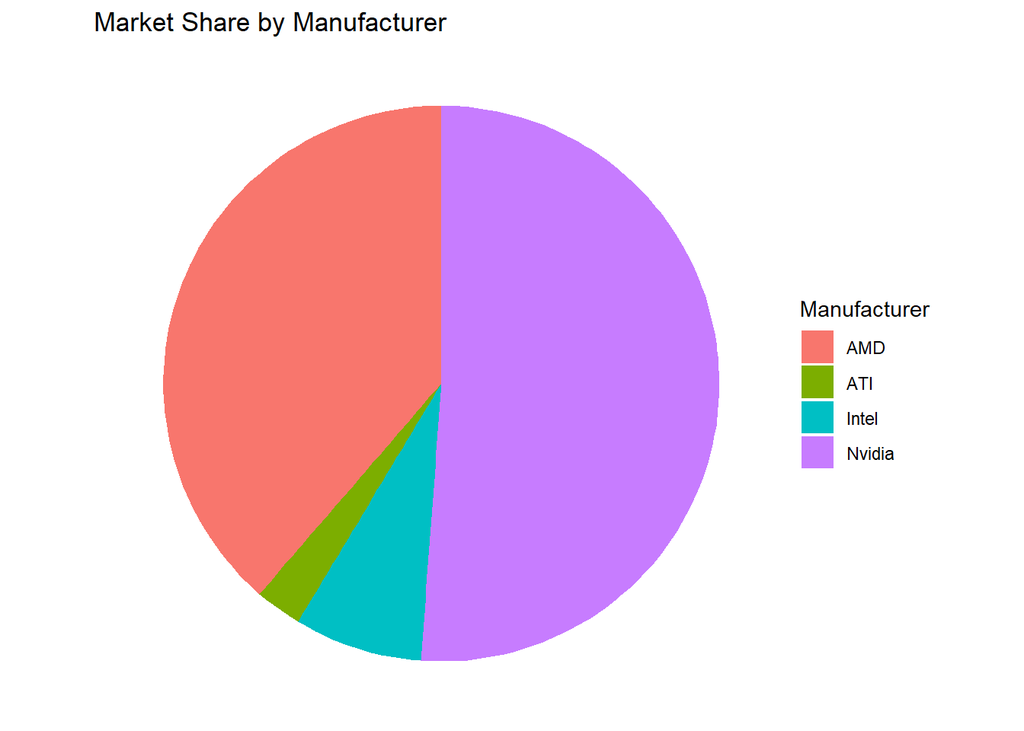

```r
manufacturer_counts <- data_raw %>%
  count(Manufacturer, name = "Count") %>%
  filter(!is.na(Manufacturer))

ggplot(manufacturer_counts, aes(x = "", y = Count, fill = Manufacturer)) +
  geom_bar(stat = "identity", width = 1) +
  coord_polar(theta = "y") +
  labs(title = "Market Share by Manufacturer") +
  theme_void() +
  theme(legend.position = "right")
```

### Release Trends Over Time

We analyze the number of GPU models released annually and monthly to identify trends.

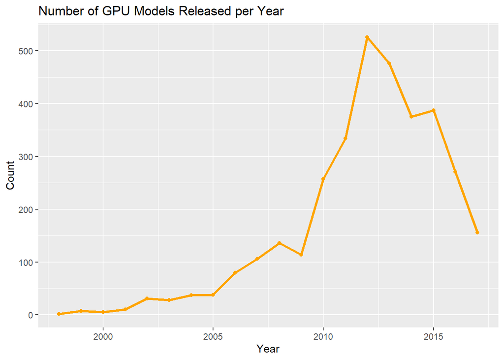

```r
# Count of models released per year
release_year_count <- data_raw %>%
  filter(!is.na(Release_Year)) %>%
  count(Release_Year, name = "Count")

ggplot(release_year_count, aes(x = Release_Year, y = Count)) +
  geom_line(color = "orange", size = 1.2) +
  geom_point(color = "orange") +
  labs(title = "Number of GPU Models Released per Year", x = "Year", y = "Count")
```

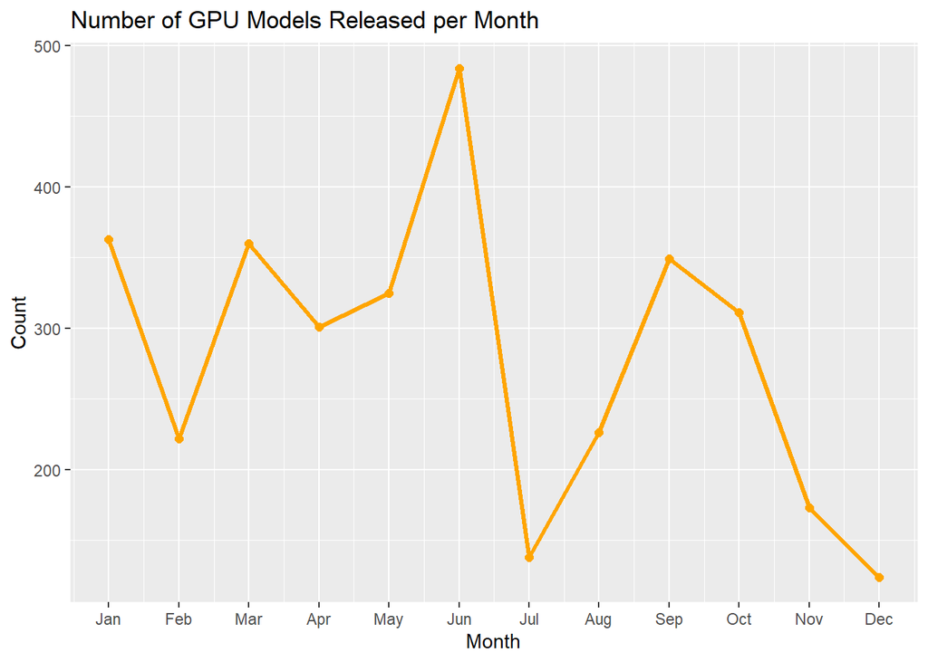

```r
# Count of models released per month (total across all years)
release_month_count <- data_raw %>%
  filter(!is.na(Release_Month)) %>%
  count(Release_Month, name = "Count") %>%
  mutate(Month_Num = match(as.character(Release_Month), month.abb)) %>%
  arrange(Month_Num)

ggplot(release_month_count, aes(x = Month_Num, y = Count)) +
  geom_line(color = "orange", size = 1.2) +
  geom_point(color = "orange", size = 2) +
  scale_x_continuous(breaks = 1:12, labels = month.abb) +
  labs(title = "Number of GPU Models Released per Month",
       x = "Month",
       y = "Count")
```

### Price and Performance Trends

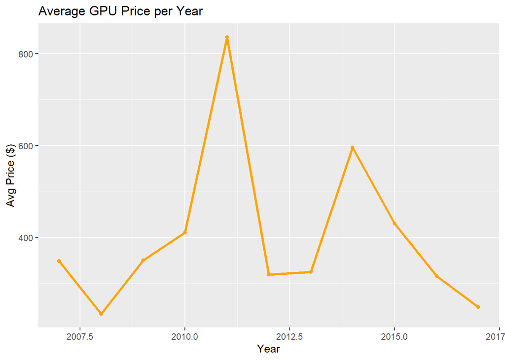

```r
# Average GPU price per year
price_year <- data_raw %>%
  filter(!is.na(Release_Price) & !is.na(Release_Year)) %>%
  group_by(Release_Year) %>%
  summarise(Avg_Price = mean(Release_Price, na.rm=TRUE))

ggplot(price_year, aes(x = Release_Year, y = Avg_Price)) +
  geom_line(color = "orange", size = 1.2) +
  geom_point(color = "orange") +
  labs(title = "Average GPU Price per Year", x = "Year", y = "Avg Price ($)")
```

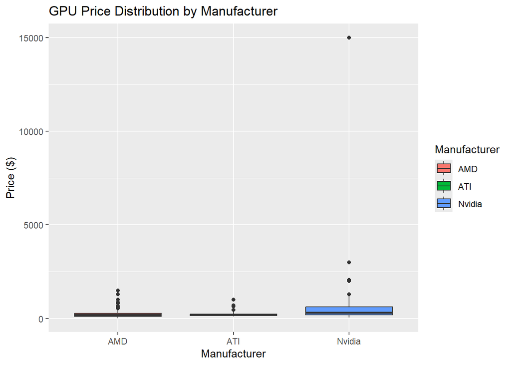

```r
# GPU price distribution by manufacturer
ggplot(data_raw %>% filter(!is.na(Release_Price) & !is.na(Manufacturer)),
       aes(x = Manufacturer, y = Release_Price, fill = Manufacturer)) +
  geom_boxplot() +
  labs(title = "GPU Price Distribution by Manufacturer", x = "Manufacturer", y = "Price ($)")
```

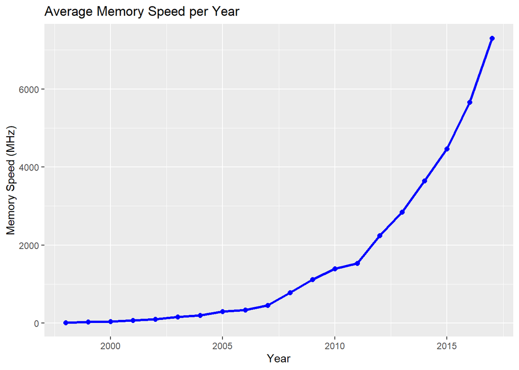

```r
# Average Memory Speed per Year
memory_year <- data_raw %>%
  filter(!is.na(Release_Year)) %>%
  group_by(Release_Year) %>%
  summarise(Avg_Memory = mean(Memory, na.rm = TRUE))

ggplot(memory_year, aes(x = Release_Year, y = Avg_Memory)) +
  geom_line(color = "blue", size = 1.2) +
  geom_point(color = "blue", size = 2) +
  labs(title = "Average Memory Speed per Year",
       x = "Year",
       y = "Memory Speed (MHz)")
```

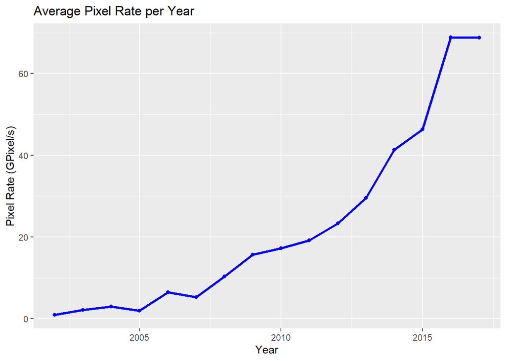

```r
# Average Pixel Rate per Year
pixel_year <- data_raw %>%
  filter(!is.na(Release_Year) & !is.na(Pixel_Rate)) %>%
  group_by(Release_Year) %>%
  summarise(Avg_Pixel_Rate = mean(Pixel_Rate, na.rm = TRUE))

ggplot(pixel_year, aes(x = Release_Year, y = Avg_Pixel_Rate)) +
  geom_line(color = "blue", size = 1.2) +
  geom_point(color = "blue") +
  labs(title = "Average Pixel Rate per Year", x = "Year", y = "Pixel Rate (GPixel/s)")
```